# OSYM 2017

## Results and MEF University Evaluation

According to OSYM 2017 results, nearly 1.8 million candidate get the rigt to choose a program and nearly 1 million of them did. After the placement of those who choose a program, placements and empty quota for each program, the highest and lowest scores of the programs have been occured. According to this criteria, we wil evaluate which universities and programs are preferred more, what is the mean maximum and mean minimum scores of the programs, how MEF University’s results and position compared to other universities adn where MEF University should focus in coming years in order to stranghten its position among other private and state universities in Istanbul.

```r
library(dplyr)
library(ggplot2)
library(tidyverse)
library(knitr)
library(stringr)
library(plotly)
library(kableExtra)

load("osym_data_2017_v2.RData")
nrow(osym_data_2017)
```

```
## [1] 11465
```

We will evaluate the results according to factors below:

```r
names(osym_data_2017)
```

```
##  [1] "program_id"        "university_name"   "city"
##  [4] "faculty_name"      "program_name"      "exam_type"
##  [7] "general_quota"     "general_placement" "min_score"
## [10] "max_score"         "val_quota"         "val_placement"
## [13] "val_min_score"     "val_max_score"
```

In order to evaluate the results, we need to enrich our data with new measures like:  
* **university_id**,  
* **uni_type** (private or state)  
* **score_gap** (gap between max and min scores of a program)  
* **fullness** (if the quota of a program is full or not).

```r
osym_data_2017$general_placement<-as.integer(osym_data_2017$general_placement)
osym_data_2017$general_quota<-as.integer(osym_data_2017$general_quota)
osym_data_2017$score_gap<-osym_data_2017$max_score-osym_data_2017$min_score
osym_data_2017$fullness<-round((osym_data_2017$general_placement/osym_data_2017$general_quota),2)
osym_data_2017$university_id<-substring(osym_data_2017$program_id,1,4)
osym_data_2017$university_typeid<-substring(osym_data_2017$program_id,1,1)
osym_data_2017$university_type<-osym_data_2017$university_typeid
osym_data_2017$counter<-1

#replace university_typeid with definition in order to make our analysis more clear
vect<-ifelse(osym_data_2017$university_type==1,"State","Private")
vect2<-ifelse(substr(osym_data_2017$exam_type,3,6)=="L_1","DL_1",osym_data_2017$exam_type)
osym_data_2017$university_type<-vect
osym_data_2017$exam_type<-vect2
```

Also we only take universities into consideration which are located in Turkey, so we are eleminating Universities in Northern Cyprus and abroad.

```r
osym_data_2017<-osym_data_2017[osym_data_2017$university_typeid<3, ]
nrow(osym_data_2017)
```

```
## [1] 10186
```

### General Facts

```r
universities<-osym_data_2017 %>% group_by(university_name, university_type) %>% summarise()
table(universities$university_type)
```

```
##
## Private   State
##      63     109
```

```r
#use the last character of the program name in order to eleminate different types of same program.

programs<-osym_data_2017 %>% group_by(program_name) %>%summarise()
unique_programs<-programs%>% filter(str_sub(program_name,-1,-1) != ")")
sprintf("Unique programs: %i",nrow(unique_programs))
```

```
## [1] "Unique programs: 320"
```

```r
sprintf("Total programs: %i",nrow(programs))
```

```
## [1] "Total programs: 1971"
```

```r
head(osym_data_2017 %>% group_by(city) %>%  summarise(quota=sum(general_quota), quota_p=quota/sum(osym_data_2017$general_quota) ) %>% arrange(desc(quota)),3)
```

```
## # A tibble: 3 x 3
##        city  quota    quota_p
##       <chr>  <int>      <dbl>
## 1  ISTANBUL 100078 0.19511235
## 2 ESKISEHIR  64169 0.12510406
## 3    ANKARA  37124 0.07237705
```

#### Which Programs are top students’ choice?

```r
top_programs<-osym_data_2017 %>% group_by(university_name, program_name) %>% summarise(min_score=min(min_score))%>% arrange(desc(min_score))
top10_prog<-head(top_programs,10)
kable(top10_prog)
```

| university_name | program_name | min_score |
| --- | --- | --- |
| KOÇ ÜNIVERSITESI | Tip (Ingilizce) (Tam Burslu) | 543.7331 |
| KOÇ ÜNIVERSITESI | Elektrik - Elektronik Mühendisligi (Ingilizce) (Tam Burslu) | 541.1376 |
| ISTANBUL MEDIPOL ÜNIVERSITESI | Tip Fakültesi (Ingilizce) (Tam Burslu) | 537.6752 |
| KOÇ ÜNIVERSITESI | Bilgisayar Mühendisligi (Ingilizce) (Tam Burslu) | 535.2476 |
| BOGAZIÇI ÜNIVERSITESI | Elektrik - Elektronik Mühendisligi (Ingilizce) | 530.0887 |
| ISTANBUL ÜNIVERSITESI | Cerrahpasa Tip (Ingilizce) | 529.1756 |
| KOÇ ÜNIVERSITESI | Hukuk (Tam Burslu) | 526.9244 |
| IHSAN DOGRAMACI BILKENT ÜNIVERSITESI | Elektrik - Elektronik Mühendisligi (Ingilizce) (Tam Burslu) | 526.7218 |
| GALATASARAY ÜNIVERSITESI | Hukuk | 524.7550 |
| BOGAZIÇI ÜNIVERSITESI | Bilgisayar Mühendisligi (Ingilizce) | 524.2180 |

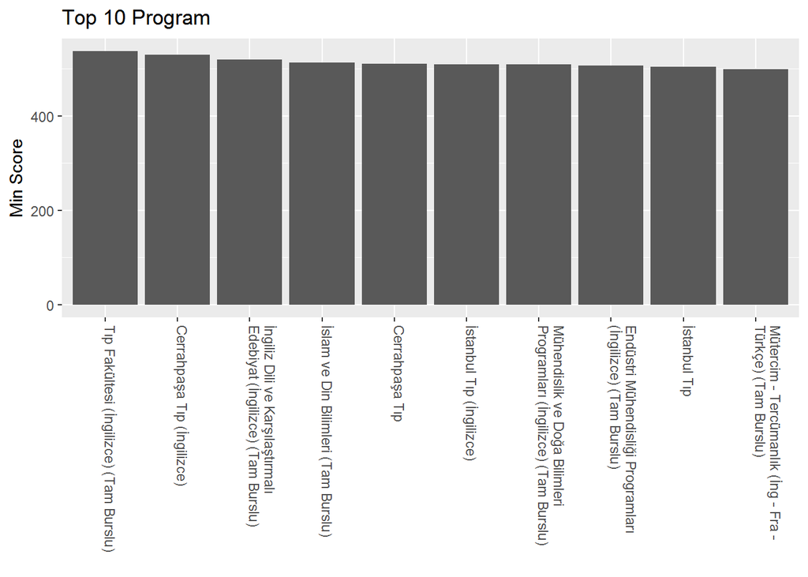

```r
graph1 <- osym_data_2017 %>%
  select(program_name,university_name, min_score, city)  %>% group_by(program_name)%>%
  summarise(minScore=min(min_score)) %>%
  arrange(desc(minScore))

top10<-head(graph1,10)

ggplot(top10, aes(x=reorder(program_name,-minScore), y=minScore)) +
  geom_bar(stat = "identity") +
  labs(title="Top 10 Program",x="", y="Min Score",fill="black") +
  theme (axis.text.x=element_text (angle=-90,vjust=0,hjust=0)) +
  scale_x_discrete(labels = function(x) lapply(strwrap(x, width = 40, simplify = FALSE), paste, collapse="\n"))
```

### About MEF

MEF university accepted students with **5** different exam types for **15** different programs. Univercity announced quota for total **817** students and after the results, **768** students placed to a program at MEF Univercity which means MEF University had an average **94%** fullnes for their programs.

```r
mef_data<-osym_data_2017  %>% filter (university_id=="2072")

sprintf("Total quota of MEF: %i",sum(mef_data$general_quota))
```

```
## [1] "Total quota of MEF: 817"
```

```r
sprintf("Total placement of MEF: %i",sum(mef_data$general_placement))
```

```
## [1] "Total placement of MEF: 768"
```

```r
mef_exam_type<-osym_data_2017  %>% filter (university_id=="2072") %>% group_by(exam_type) %>%  summarise(quota=sum(general_quota),placement=sum(general_placement) , space=sum(general_quota)-sum(placement), fullness=round(sum(general_placement)/sum(general_quota),2))%>% arrange(desc(quota))
kable(mef_exam_type)
```

| exam_type | quota | placement | space | fullness |
| --- | --- | --- | --- | --- |
| TM_3 | 350 | 315 | 35 | 0.90 |
| MF_4 | 327 | 327 | 0 | 1.00 |
| TM_1 | 80 | 66 | 14 | 0.82 |
| DL_1 | 40 | 40 | 0 | 1.00 |
| MF_1 | 20 | 20 | 0 | 1.00 |

If we look at the table above, MEF University had a %100 fullnes for the programs in DIL_1, MF_1 and MF_4 exam types. On the other hand 82% fullness in TM_1 and 90% fullnes in TM_3 has been reached. **According to this results, MEF University should focus on programs in TM exam types while keep its achivement in other 3 exam types.**

**If we look deeper, we can see that Faculty of Education has 35 empty space (27% of all quota) so MEF University should focus on increase the reputation of Faculty of Education.**

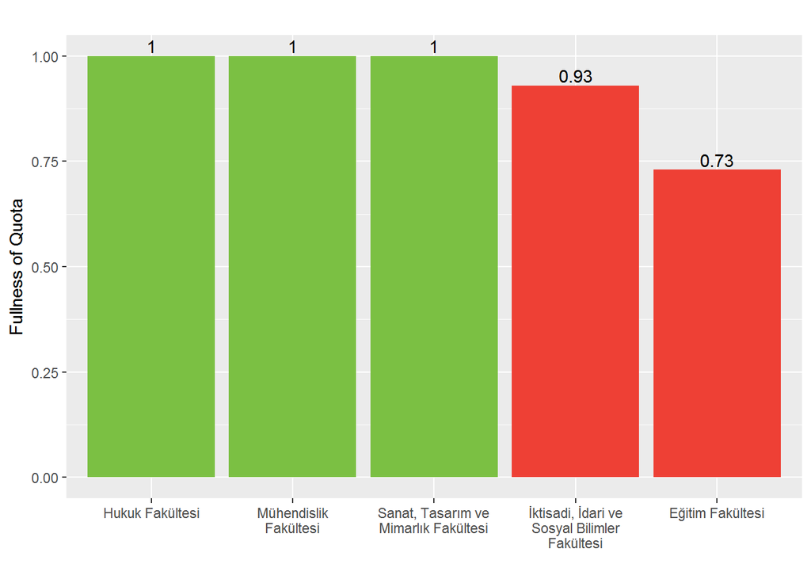

```r
mef_faculty<-osym_data_2017  %>% filter (university_id=="2072") %>% group_by(faculty_name) %>%  summarise(quota=sum(general_quota),placement=sum(general_placement) , space=sum(general_quota)-sum(placement), fullness=round(sum(general_placement)/sum(general_quota),2))%>% arrange(desc(fullness))

ggplot(mef_faculty, aes(x=reorder(faculty_name,-fullness), y=fullness)) +
  geom_bar(stat = "identity", aes(fill= fullness < 1 )) +
  labs(title="",x="", y="Fullness of Quota") +
  theme (axis.text.x=element_text (angle=0,vjust=1,hjust=0.5) ) +
  scale_x_discrete(labels = function(x) lapply(strwrap(x, width = 20, simplify = FALSE), paste, collapse="\n"))+scale_fill_manual(values = c('#7bc043','#ee4035'),guide=FALSE)+geom_text(aes(label=fullness), position=position_dodge(width=0.9), vjust=-0.25)
```

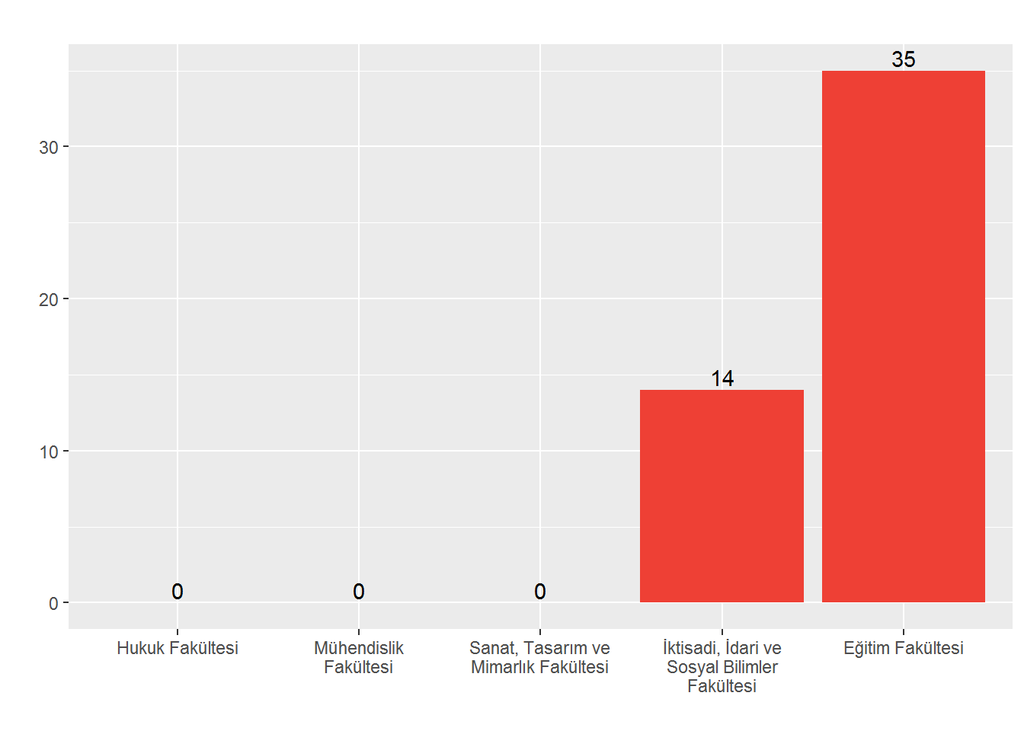

```r
ggplot(mef_faculty, aes(x=reorder(faculty_name,space), y=space)) +
  geom_bar(stat = "identity", aes(fill= space > 0.1*sum(quota) )) +
  labs(title="",x="", y="") +
  theme (axis.text.x=element_text (angle=0,vjust=1,hjust=0.5) ) +
  scale_x_discrete(labels = function(x) lapply(strwrap(x, width = 20, simplify = FALSE), paste, collapse="\n"))+scale_fill_manual(values = c('#ee4035','grey'),guide=FALSE)+geom_text(aes(label=space), position=position_dodge(width=0.9), vjust=-0.25)
```

MEF University has only 3 programs which is not totally full out of 44 programs. If we look at these programs, we can see that all 3 program is 50% scholarship programs. As a result, we can say that MEF University should not offer less than 50% scholarship in these 3 programs.

```r
mef_empty_prog<-osym_data_2017  %>%  filter (university_id=="2072") %>% group_by(program_name) %>%  summarise(quota=sum(general_quota),placement=sum(general_placement) , space=sum(general_quota)-sum(placement), fullness=round(sum(general_placement)/sum(general_quota),2))%>% arrange(desc(space))%>% filter (fullness<1)
kable(mef_empty_prog)
```

| program_name | quota | placement | space | fullness |
| --- | --- | --- | --- | --- |
| Rehberlik ve Psikolojik Danismanlik (Ingilizce) (%50 Burslu) | 60 | 25 | 35 | 0.42 |
| Ekonomi (Ingilizce) (%50 Burslu) | 22 | 10 | 12 | 0.45 |
| Isletme (Ingilizce) (%50 Burslu) | 22 | 20 | 2 | 0.91 |

#### *So far we have talked about quotas and placement numbers. Now, lets evaluate the programs according to the minimum and maximum scores of the students placed.*

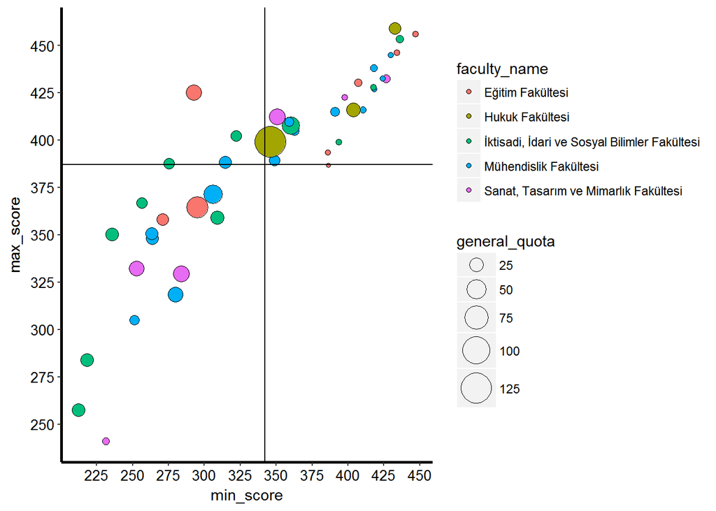

```r
ggplot(mef_prog_score, aes(x = min_score, y = max_score, size = general_quota, fill=faculty_name)) +
        geom_point(shape = 21)+ scale_x_continuous(breaks = seq(200, 500, 25))+ scale_y_continuous(breaks = seq(200, 500, 25))+ scale_size_area(max_size = 10)+ theme(axis.line = element_line(size=1, colour = "black"),
              panel.grid.major = element_blank(),
              panel.grid.minor = element_blank(),
              panel.border = element_blank(),
              panel.background = element_blank(),axis.text.x=element_text(colour="black", size = 10),
              axis.text.y=element_text(colour="black", size = 10))+geom_hline(yintercept = 387)+geom_vline(xintercept = 342)
```

### MEF vs. Benchmarks

```
##
## Private   State
##      41      10
```

```
## [1] 82796
```

We assume that MEF University should be compared to Private or State Universities in Istanbul. So all the comparisons will be made according to this assumption. There are **10 State** and **41 Private** Universities in Istnbul. Total placement at these universities is **82796**

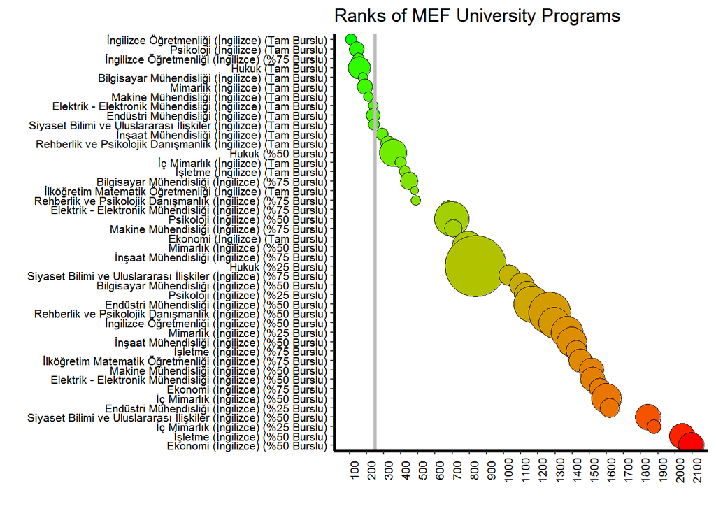

[output not shown]

```r
mef_examtype<-c("MF_1","MF_4","TM_1","TM_3","DL_1")
benchmark2<-osym_data_2017 %>% filter(substr(osym_data_2017$city,2,8)=="STANBUL", exam_type %in% mef_examtype) %>% arrange(desc(min_score))%>% mutate(rank=row_number())

mef_prog_rank<-benchmark2%>% filter(university_id=="2072")%>%arrange(desc(-rank))

ggplot(mef_prog_rank, aes(y = reorder(program_name,-rank), x = rank, size=general_quota, fill=-rank )) +scale_fill_continuous(low = "red", high = "green")+
        geom_point(shape=21)+ scale_x_continuous(breaks = seq(0, 2300, 100))+ scale_size_area(max_size = 20)+ theme(axis.line = element_line(size=1, colour = "black"),
              panel.grid.major = element_blank(),
              panel.grid.minor = element_blank(),
              panel.border = element_blank(),
              panel.background = element_blank(),axis.text.x=element_text(colour="black", size = 8, angle=90),
              axis.text.y=element_text(colour="black", size = 8))+geom_vline(xintercept = 250, size=1.2, colour="grey")+ theme(legend.position = "none")+labs(title="Ranks of MEF University Programs",x="", y="",fill="black")
```

When we compare MEF University directly to the private universities in Istanbul according to average rank of the offered programs, MEF seems like 5th best private university in Istanbul with an average rank of 700 in all prorams. However, varience between the best and the worst ranked program of MEF university quite big so MEF University should focus close this gap.

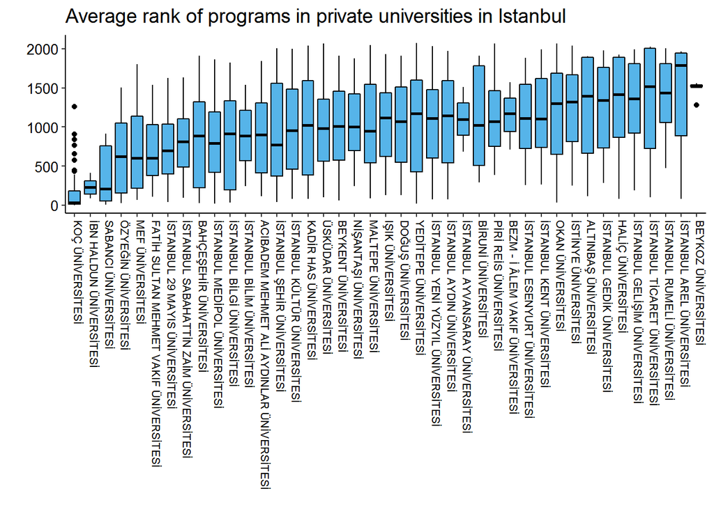

```r
benchmark4<-osym_data_2017 %>% filter(substr(osym_data_2017$city,2,8)=="STANBUL", university_type=="Private",exam_type %in% mef_examtype) %>% arrange(desc(min_score))%>% mutate(rank=row_number())

benchmark5<-benchmark3 %>% select(university_name, rank)

ggplot(benchmark5, aes(reorder(x = university_name, rank), y = rank)) +
        geom_boxplot(colour = "black", fill = "#56B4E9")+labs(title="Average rank of programs in private universities in İstanbul",x="", y="",fill="black")+theme(axis.line.x = element_line(size = 0.5, colour = "black"),
              axis.line.y = element_line(size = 0.5, colour = "black"),
              axis.line = element_line(size=1, colour = "black"),
              panel.grid.major = element_blank(),
              panel.grid.minor = element_blank(),
              panel.border = element_blank(),
              panel.background = element_blank(),
              plot.title=element_text(size = 14),
              text=element_text(size = 10),
              axis.text.x=element_text(colour="black", size = 8, angle=-90, vjust=0, hjust=0),
              axis.text.y=element_text(colour="black", size = 10))
```